# Project

Harsh

25/07/2020

- Importing all required libraries

```r
#Importing Libraries

#install.packages("rattle")
#install.packages("DataExplorer")
#install.packages("factoextra")

library(factoextra)
library(DataExplorer)
library(caret)
library(psych)
library(ggplot2)
library(gridExtra)
library(grid)
library(GGally)
library(reshape2)
library(C50)
library(gmodels)
library(rpart)
library(rpart.plot)
library(rattle)
library(neuralnet)
library(kernlab)
library(caretEnsemble)
library(pROC)
library(Metrics)
library(OneR)
library(tm)
library(wordcloud)
library(RColorBrewer)
```

1. Data Acquisition
- For Importing data, I have used read.csv function.
- Using head function, I observed first few rows of the data
- Since almost all the features are categorical, I have kept stringsAsFactors = True

```r
#Importing Dataset
data <- read.csv("C:\\Users\\harsh\\Desktop\\Introduction to Machine learning and Data Mining\\Project\\survey.csv",stringsAsFactors = TRUE)

#Exploring Dataset
head(data)
```

|  | Timestamp | Age | Gender | Country | state | self_employed | family_history | treatment | work_interfere | no_employees | remote_work | tech_company | benefits | care_options | wellness_program | seek_help | anonymity | leave | mental_health_consequence | phys_health_consequence | coworkers | supervisor | mental_health_interview | phys_health_interview | mental_vs_physical | obs_consequence | comments |
| --- | --- | --- | --- | --- | --- | --- | --- | --- | --- | --- | --- | --- | --- | --- | --- | --- | --- | --- | --- | --- | --- | --- | --- | --- | --- | --- | --- |
| 1 | 2014-08-27 11:29:31 | 37 | Female | United States | IL | NA | No | Yes | Often | 6-25 | No | Yes | Yes | Not sure | No | Yes | Yes | Somewhat easy | No | No | Some of them | Yes | No | Maybe | Yes | No | NA |
| 2 | 2014-08-27 11:29:37 | 44 | M | United States | IN | NA | No | No | Rarely | More than 1000 | No | No | Don't know | No | Don't know | Don't know | Don't know | Don't know | Maybe | No | No | No | No | No | Don't know | No | NA |
| 3 | 2014-08-27 11:29:44 | 32 | Male | Canada | NA | NA | No | No | Rarely | 6-25 | No | Yes | No | No | No | No | Don't know | Somewhat difficult | No | No | Yes | Yes | Yes | Yes | No | No | NA |
| 4 | 2014-08-27 11:29:46 | 31 | Male | United Kingdom | NA | NA | Yes | Yes | Often | 26-100 | No | Yes | No | Yes | No | No | No | Somewhat difficult | Yes | Yes | Some of them | No | Maybe | Maybe | No | Yes | NA |
| 5 | 2014-08-27 11:30:22 | 31 | Male | United States | TX | NA | No | No | Never | 100-500 | Yes | Yes | Yes | No | Don't know | Don't know | Don't know | Don't know | No | No | Some of them | Yes | Yes | Yes | Don't know | No | NA |
| 6 | 2014-08-27 11:31:22 | 33 | Male | United States | TN | NA | Yes | No | Sometimes | 6-25 | No | Yes | Yes | Not sure | No | Don't know | Don't know | Don't know | No | No | Yes | Yes | No | Maybe | Don't know | No | NA |

2. Data Exploration

### Exploratory data plots

- I have used plot_intro function from DataExplorer package
- plot_intro provides an insight of what type of data is present along with that it provides the information about missing values
- Apart from that, I have used str and summary to understand the structure of the data present
- To calculate the number of NA present in the data I have created a function inside sapply it returns column name and NA present in it
- To get a better understanding of the distribution of the data, I have plotted each column in barplot
- In the plots we can observe Age, Gender, self_employed, work_interfere columns need to be cleaned

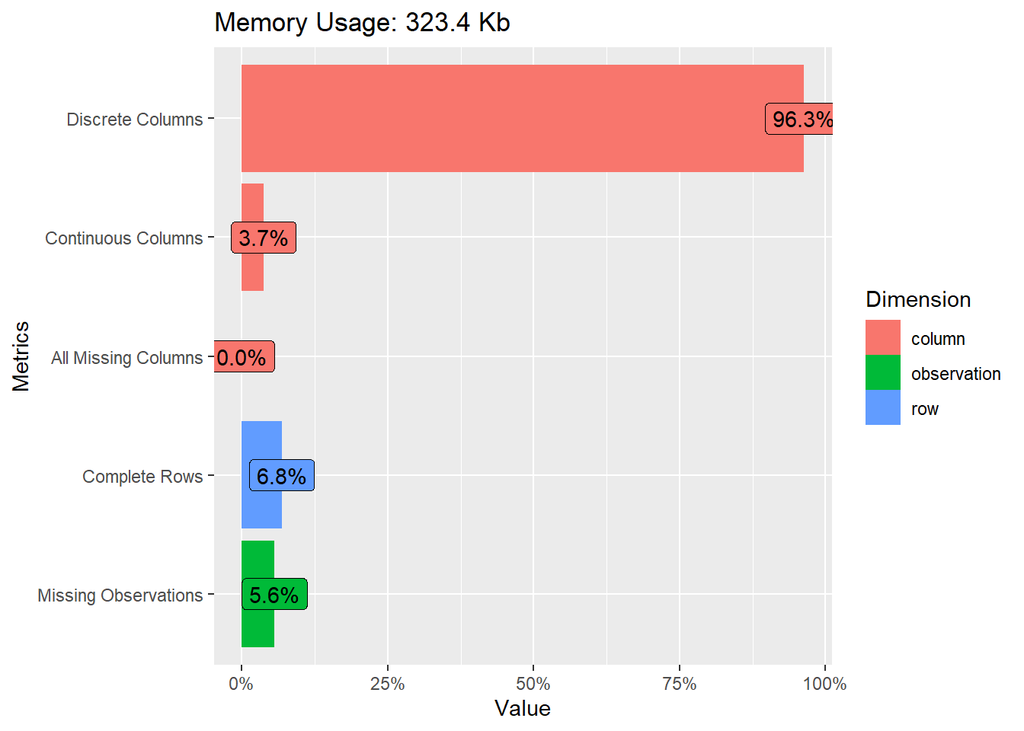

```r
##############################
### Exploratory data plots ###
##############################

#Visualizing structure of the dataset
plot_intro(data)
```

```r
#Exploratory Analysis
str(data)
```

```
## 'data.frame':    1259 obs. of  27 variables:
##  $ Timestamp                : Factor w/ 1246 levels "2014-08-27 11:29:31",..: 1 2 3 4 5 6 7 8 9 10 ...
##  $ Age                      : num  37 44 32 31 31 33 35 39 42 23 ...
##  $ Gender                   : Factor w/ 49 levels "A little about you",..: 16 24 30 30 30 30 16 24 16 30 ...
##  $ Country                  : Factor w/ 48 levels "Australia","Austria",..: 46 46 8 45 46 46 46 8 46 8 ...
##  $ state                    : Factor w/ 45 levels "AL","AZ","CA",..: 11 12 NA NA 38 37 19 NA 11 NA ...
##  $ self_employed            : Factor w/ 2 levels "No","Yes": NA NA NA NA NA NA NA NA NA NA ...
##  $ family_history           : Factor w/ 2 levels "No","Yes": 1 1 1 2 1 2 2 1 2 1 ...
##  $ treatment                : Factor w/ 2 levels "No","Yes": 2 1 1 2 1 1 2 1 2 1 ...
##  $ work_interfere           : Factor w/ 4 levels "Never","Often",..: 2 3 3 2 1 4 4 1 4 1 ...
##  $ no_employees             : Factor w/ 6 levels "1-5","100-500",..: 5 6 5 3 2 5 1 1 2 3 ...
##  $ remote_work              : Factor w/ 2 levels "No","Yes": 1 1 1 1 2 1 2 2 1 1 ...
##  $ tech_company             : Factor w/ 2 levels "No","Yes": 2 1 2 2 2 2 2 2 2 2 ...
##  $ benefits                 : Factor w/ 3 levels "Don't know","No",..: 3 1 2 2 3 3 2 2 3 1 ...
##  $ care_options             : Factor w/ 3 levels "No","Not sure",..: 2 1 1 3 1 2 1 3 3 1 ...
##  $ wellness_program         : Factor w/ 3 levels "Don't know","No",..: 2 1 2 2 1 2 2 2 2 1 ...
##  $ seek_help                : Factor w/ 3 levels "Don't know","No",..: 3 1 2 2 1 1 2 2 2 1 ...
##  $ anonymity                : Factor w/ 3 levels "Don't know","No",..: 3 1 1 2 1 1 2 3 2 1 ...
##  $ leave                    : Factor w/ 5 levels "Don't know","Somewhat difficult",..: 3 1 2 2 1 1 2 1 4 1 ...
##  $ mental_health_consequence: Factor w/ 3 levels "Maybe","No","Yes": 2 1 2 3 2 2 1 2 1 2 ...
##  $ phys_health_consequence  : Factor w/ 3 levels "Maybe","No","Yes": 2 2 2 3 2 2 1 2 2 2 ...
##  $ coworkers                : Factor w/ 3 levels "No","Some of them",..: 2 1 3 2 2 3 2 1 3 3 ...
##  $ supervisor               : Factor w/ 3 levels "No","Some of them",..: 3 1 3 1 3 3 1 1 3 3 ...
##  $ mental_health_interview  : Factor w/ 3 levels "Maybe","No","Yes": 2 2 3 1 3 2 2 2 2 1 ...
##  $ phys_health_interview    : Factor w/ 3 levels "Maybe","No","Yes": 1 2 3 1 3 1 2 2 1 1 ...
##  $ mental_vs_physical       : Factor w/ 3 levels "Don't know","No",..: 3 1 2 2 1 1 1 2 2 3 ...
##  $ obs_consequence          : Factor w/ 2 levels "No","Yes": 1 1 1 2 1 1 1 1 1 1 ...
##  $ comments                 : Factor w/ 160 levels "-"," ","(yes but the situation was unusual and involved a change in leadership at a very high level in the organization"| __truncated__,..: NA NA NA NA NA NA NA NA NA NA ...
```

```r
summary(data)
```

```
##                Timestamp         Age                 Gender
##  2014-08-27 12:31:41:   2   Min.   :-1.726e+03   Male   :615
##  2014-08-27 12:37:50:   2   1st Qu.: 2.700e+01   male   :206
##  2014-08-27 12:43:28:   2   Median : 3.100e+01   Female :121
##  2014-08-27 12:44:51:   2   Mean   : 7.943e+07   M      :116
##  2014-08-27 12:54:11:   2   3rd Qu.: 3.600e+01   female : 62
##  2014-08-27 14:22:43:   2   Max.   : 1.000e+11   F      : 38
##  (Other)            :1247                        (Other):101
##            Country        state     self_employed family_history treatment
##  United States :751   CA     :138   No  :1095     No :767        No :622
##  United Kingdom:185   WA     : 70   Yes : 146     Yes:492        Yes:637
##  Canada        : 72   NY     : 57   NA's:  18
##  Germany       : 45   TN     : 45
##  Ireland       : 27   TX     : 44
##  Netherlands   : 27   (Other):390
##  (Other)       :152   NA's   :515
##    work_interfere         no_employees remote_work tech_company
##  Never    :213    1-5           :162   No :883     No : 228
##  Often    :144    100-500       :176   Yes:376     Yes:1031
##  Rarely   :173    26-100        :289
##  Sometimes:465    500-1000      : 60
##  NA's     :264    6-25          :290
##                   More than 1000:282
##
##        benefits     care_options   wellness_program      seek_help
##  Don't know:408   No      :501   Don't know:188     Don't know:363
##  No        :374   Not sure:314   No        :842     No        :646
##  Yes       :477   Yes     :444   Yes       :229     Yes       :250
##
##
##
##
##       anonymity                  leave     mental_health_consequence
##  Don't know:819   Don't know        :563   Maybe:477
##  No        : 65   Somewhat difficult:126   No   :490
##  Yes       :375   Somewhat easy     :266   Yes  :292
##                   Very difficult    : 98
##                   Very easy         :206
##
##
```

[output cut: 17 more lines]

```
##  No :1075
##  Yes: 184
##
##
##
##
##
##                                                                                                                                                                                 comments
##  * Small family business - YMMV.                                                                                                                                                    :   5
##  -                                                                                                                                                                                  :   1
##                                                                                                                                                                                     :   1
##  (yes but the situation was unusual and involved a change in leadership at a very high level in the organization as well as an extended leave of absence)                           :   1
##  A close family member of mine struggles with mental health so I try not to stigmatize it. My employers/coworkers also seem compassionate toward any kind of health or family needs.:   1
##  (Other)                                                                                                                                                                            : 155
##  NA's                                                                                                                                                                               :1095
```

```r
sapply(data, function(x) sum(is.na(x)))
```

```
##                 Timestamp                       Age                    Gender
##                         0                         0                         0
##                   Country                     state             self_employed
##                         0                       515                        18
##            family_history                 treatment            work_interfere
##                         0                         0                       264
##              no_employees               remote_work              tech_company
##                         0                         0                         0
##                  benefits              care_options          wellness_program
##                         0                         0                         0
##                 seek_help                 anonymity                     leave
##                         0                         0                         0
## mental_health_consequence   phys_health_consequence                 coworkers
##                         0                         0                         0
##                supervisor   mental_health_interview     phys_health_interview
##                         0                         0                         0
##        mental_vs_physical           obs_consequence                  comments
##                         0                         0                      1095
```

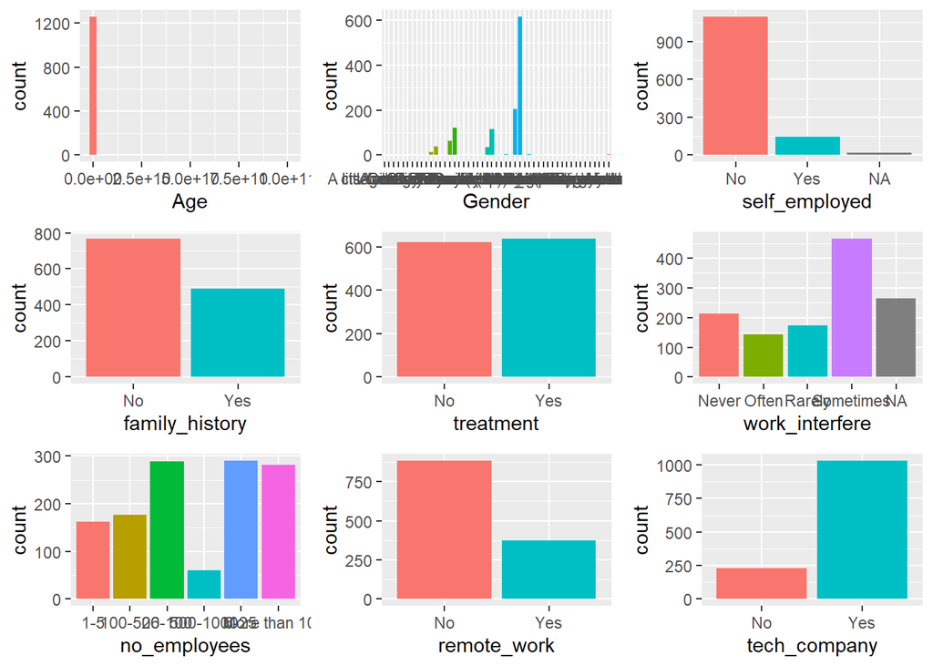

```r
#Plotting the distribution of the important features
g1 <- ggplot(data,aes(x=Age,fill="Steelblue"))+geom_histogram()+theme(legend.position = "none")
g2 <- ggplot(data,aes(x=Gender,fill=Gender))+geom_bar()+theme(legend.position = "none")
g3 <- ggplot(data,aes(x=self_employed,fill=self_employed))+geom_bar()+theme(legend.position = "none")
g4 <- ggplot(data,aes(x=family_history,fill=family_history))+geom_bar()+theme(legend.position = "none")
g5 <- ggplot(data,aes(x=treatment,fill=treatment))+geom_bar()+theme(legend.position = "none")
g6 <- ggplot(data,aes(x=work_interfere,fill=work_interfere))+geom_bar()+theme(legend.position = "none")
g7 <- ggplot(data,aes(x=no_employees,fill=no_employees))+geom_bar()+theme(legend.position = "none")
g8 <- ggplot(data,aes(x=remote_work,fill=remote_work))+geom_bar()+theme(legend.position = "none")
g9 <- ggplot(data,aes(x=tech_company,fill=tech_company))+geom_bar()+theme(legend.position = "none")
g10 <- ggplot(data,aes(x=benefits,fill=benefits))+geom_bar()+theme(legend.position = "none")
g11 <- ggplot(data,aes(x=care_options,fill=care_options))+geom_bar()+theme(legend.position = "none")
g12 <- ggplot(data,aes(x=wellness_program,fill=wellness_program))+geom_bar()+theme(legend.position = "none")
g13 <- ggplot(data,aes(x=seek_help,fill=seek_help))+geom_bar()+theme(legend.position = "none")
g14 <- ggplot(data,aes(x=anonymity,fill=anonymity))+geom_bar()+theme(legend.position = "none")
g15 <- ggplot(data,aes(x=leave,fill=leave))+geom_bar()+theme(legend.position = "none")
g16 <- ggplot(data,aes(x=mental_health_consequence,fill=mental_health_consequence))+geom_bar()+theme(legend.position = "none")
g17 <- ggplot(data,aes(x=phys_health_consequence,fill=phys_health_consequence))+geom_bar()+theme(legend.position = "none")
g18 <- ggplot(data,aes(x=coworkers,fill=coworkers))+geom_bar()+theme(legend.position = "none")
g19 <- ggplot(data,aes(x=supervisor,fill=supervisor))+geom_bar()+theme(legend.position = "none")
g20 <- ggplot(data,aes(x=mental_health_interview,fill=mental_health_interview))+geom_bar()+theme(legend.position = "none")
g21 <- ggplot(data,aes(x=phys_health_interview,fill=phys_health_interview))+geom_bar()+theme(legend.position = "none")
g22 <- ggplot(data,aes(x=mental_vs_physical,fill=mental_vs_physical))+geom_bar()+theme(legend.position = "none")
g23 <- ggplot(data,aes(x=obs_consequence,fill=obs_consequence))+geom_bar()+theme(legend.position = "none")

#Arranging the plots using grid.arrange function
grid.arrange(g1,g2,g3,g4,g5,g6,g7,g8,g9,nrow=3)
```

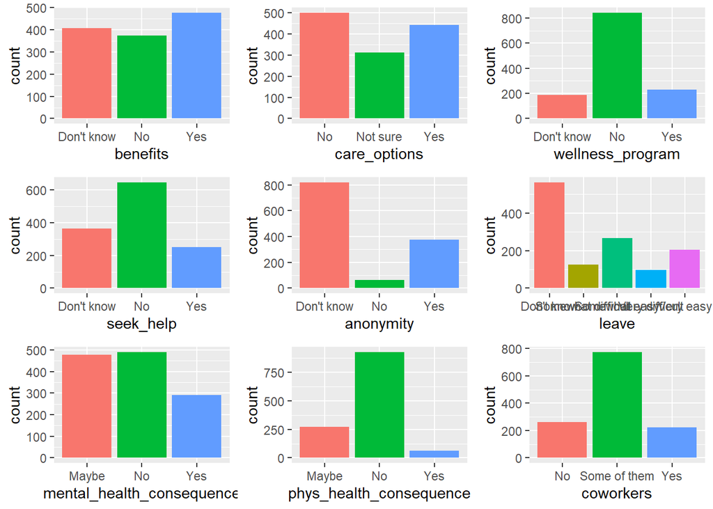

```r
grid.arrange(g10,g11,g12,g13,g14,g15,g16,g17,g18,nrow=3)
```

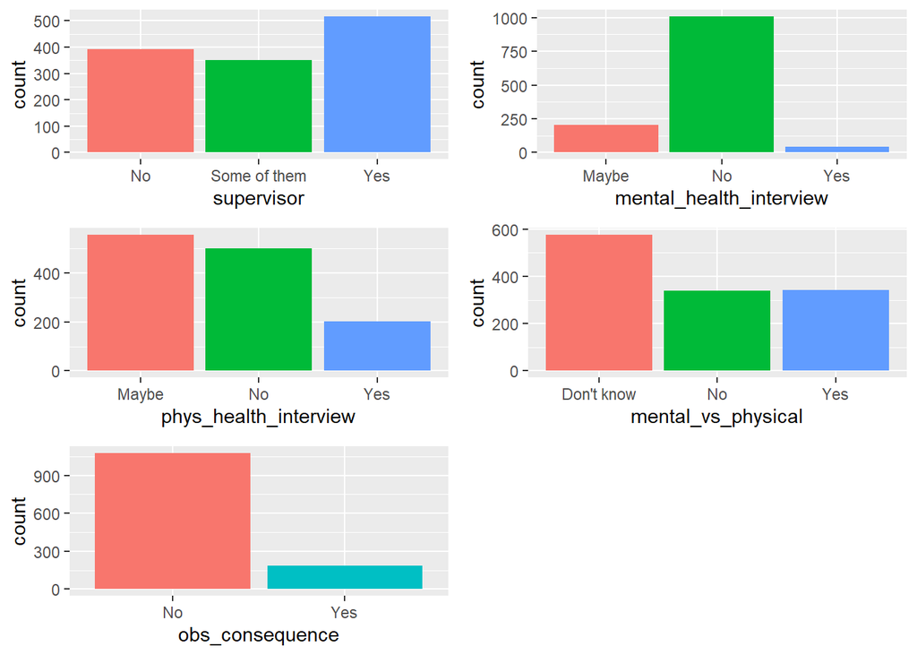

```r
grid.arrange(g19,g20,g21,g22,g23,nrow=3)
```

### Detection of outliers and data imputation

- I have checked only the age column since it is the only numerical column present in the whole dataset
- On observing the box plot and summary of Age column, I got to know that it has a few outliers
- This is because Age cannot contain negative values or values greater than 100
- I removed these outliers and imputed them with median value
- Apart from that, I have imputed mode values for the NA’s present in self_employed and work_interfere columns
- Lastly Gender column was also cleaned, It contained many values for each type of gender so I generalized the column
- Plots for each cleaned columns have been shown below
- I have also stored this clean data in a new TableauDataCSV file for making a dashboard in Tableau.

```r
##################################################
### Detection of outliers and Data imputation  ###
##################################################

#Creating a copy of data
MH_data <- data

#Mode function used to calculate mode
Mode <- function(x)
  {
    ux <- unique(x)
    ux[which.max(tabulate(match(x,ux)))]
  }

#Cleaning Age Column
summary(MH_data$Age)
```

```
##       Min.    1st Qu.     Median       Mean    3rd Qu.       Max.
## -1.726e+03  2.700e+01  3.100e+01  7.943e+07  3.600e+01  1.000e+11
```

```r
#Age Column has quite a few outliers present
#We can observe these incorrect values in the summary as well as in the plots
#Obvious outlier here are -1.726e+03 and 1.000e+11.
#Replacing with NA and then Imputing using median

mean_data <- mean(MH_data$Age)
sd_data <- sd(MH_data$Age)
zscore <- abs((MH_data$Age - mean_data)/sd_data)
print(MH_data[which((zscore>3)),2])
```

```
## [1] 1e+11
```

```r
MH_data$Age <- sapply(MH_data$Age ,function(x) ifelse(x > 100 || x < 15, yes = NA,x))
sum(is.na(MH_data$Age))
```

```
## [1] 8
```

```r
MH_data$Age[is.na(MH_data$Age)] <- median(MH_data$Age,na.rm = TRUE)
sum(is.na(MH_data$Age))
```

```
## [1] 0
```

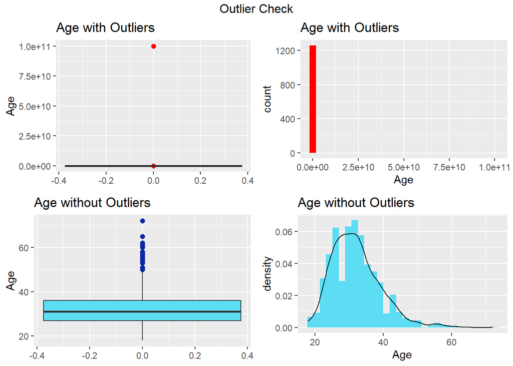

```r
#We can observe the difference in Age column before and after removing outliers
p1 <- ggplot(data,aes(y=Age),outcol="red")+geom_boxplot(outlier.colour="Red", outlier.shape=16,outlier.size=2,fill = "skyblue")+ggtitle("Age with Outliers")
p2 <- ggplot(MH_data,aes(y=Age),outcol="blue")+geom_boxplot(outlier.colour="#0827A7", outlier.shape=16,outlier.size=2,fill = "#5DDDF4")+ggtitle("Age without Outliers")
p3 <- ggplot(data,aes(x=Age))+geom_histogram(fill="red")+ggtitle("Age with Outliers")
p4 <- ggplot(MH_data,aes(x=Age))+geom_histogram(aes(y=..density..),fill="#5DDDF4")+ggtitle("Age without Outliers")+geom_density(alpha=0.5)
grid.arrange(p1,p3,p2,p4,nrow=2,top="Outlier Check")
```

```r
#Cleaning self-employed column
#On observing the summary of the data we see that self_emplyed
#column has many NA values present
summary(MH_data$self_employed)
```

```
##   No  Yes NA's
## 1095  146   18
```

```r
#Remove NA and impute mode values
#Since most of the columns are categorical
#variable imputation is done by Mode function
MH_data$self_employed[is.na(MH_data$self_employed)] <- Mode(MH_data$self_employed)
summary(MH_data$self_employed)
```

```
##   No  Yes
## 1113  146
```

```r
#Cleaning Gender column
summary(MH_data$Gender)
```

```
##                             A little about you
##                                              1
##                                        Agender
##                                              1
##                                            All
##                                              1
##                                      Androgyne
##                                              1
##                               cis-female/femme
##                                              1
##                                     Cis Female
##                                              1
##                                       cis male
##                                              1
##                                       Cis Male
##                                              2
##                                        Cis Man
##                                              1
##                                           Enby
##                                              1
##                                              f
##                                             15
##                                              F
##                                             38
##                                         femail
##                                              1
##                                         Femake
##                                              1
##                                         female
##                                             62
##                                         Female
##                                            121
##                                        Female
##                                              2
##                                   Female (cis)
##                                              1
##                                 Female (trans)
##                                              2
##                                          fluid
##                                              1
```

[output cut: 43 more lines]

```
##                                              1
##                                          queer
##                                              1
##                                 queer/she/they
##                                              1
##                          something kinda male?
##                                              1
##                                   Trans-female
##                                              1
##                                    Trans woman
##                                              1
##                                          woman
##                                              1
##                                          Woman
##                                              3
```

```r
#Gender column has a lot of error values
#Using Unique function we can observe different types of gender values
Gender_list <- unique(MH_data$Gender)
Gender_list
```

```
##  [1] Female
##  [2] M
##  [3] Male
##  [4] male
##  [5] female
##  [6] m
##  [7] Male-ish
##  [8] maile
##  [9] Trans-female
## [10] Cis Female
## [11] F
## [12] something kinda male?
## [13] Cis Male
## [14] Woman
## [15] f
```

[output cut: 35 more lines]

```r
#We create a single vector for each type of gender and assign the different values present
Male <- c("Male ", "Mail", "maile","Cis Man", "Malr", "Man", "Male", "male", "M", "cis male", "m", "Male-ish", "Mal", "Male (CIS)", "Cis Male", "Make", "Male", "msle")
Female <- c("Female ","Female","femail","woman","Female","Female (cis)","cis-female/femme", "Cis Female", "Trans woman","female","F","Woman","f","Femake", "Trans-female", "Female (trans)")
Queer <- c("Genderqueer","ostensibly male, unsure what that really means","p","A little about you","queer","Neuter", "queer/she/they","something kinda male?","non-binary","Nah","All","Enby","fluid","Androgyne","Agender","Guy (-ish) ^_^","male leaning androgynous")

#Using the new vectors we make the proper distribution of gender
MH_data$Gender <- as.factor(ifelse(MH_data$Gender %in% Male,"male",ifelse(MH_data$Gender %in% Female,"female","queer")))

#Verifying Gender Column data after cleaning
str(MH_data$Gender)
```

```
##  Factor w/ 3 levels "female","male",..: 1 2 2 2 2 2 1 2 1 2 ...
```

```r
table(MH_data$Gender)
```

```
##
## female   male  queer
##    251    991     17
```

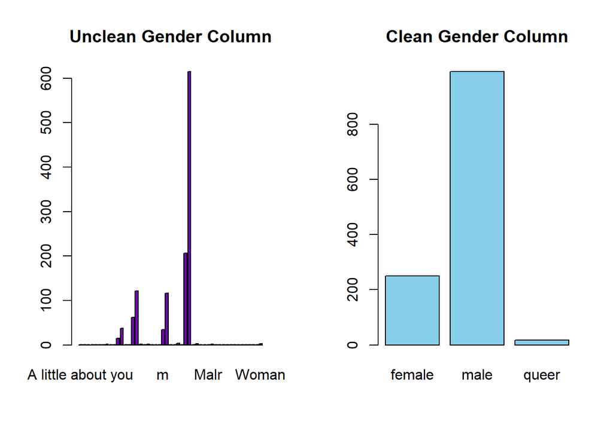

```r
par(mfrow=c(1,2))
barplot(table(data$Gender),col = "#6C0AAB",main = "Unclean Gender Column")
barplot(table(MH_data$Gender),col = "skyblue",main = "Clean Gender Column")
```

```r
#Cleaning work_interfere
#Using Summary we can see that there are around 200 NA values present
summary(MH_data$work_interfere)
```

```
##     Never     Often    Rarely Sometimes      NA's
##       213       144       173       465       264
```

```r
#Since it is a categorical variable we'll impute using mode function
MH_data$work_interfere[is.na(MH_data$work_interfere)] <- Mode(MH_data$work_interfere)
summary(MH_data$work_interfere)
```

```
##     Never     Often    Rarely Sometimes
##       213       144       173       729
```

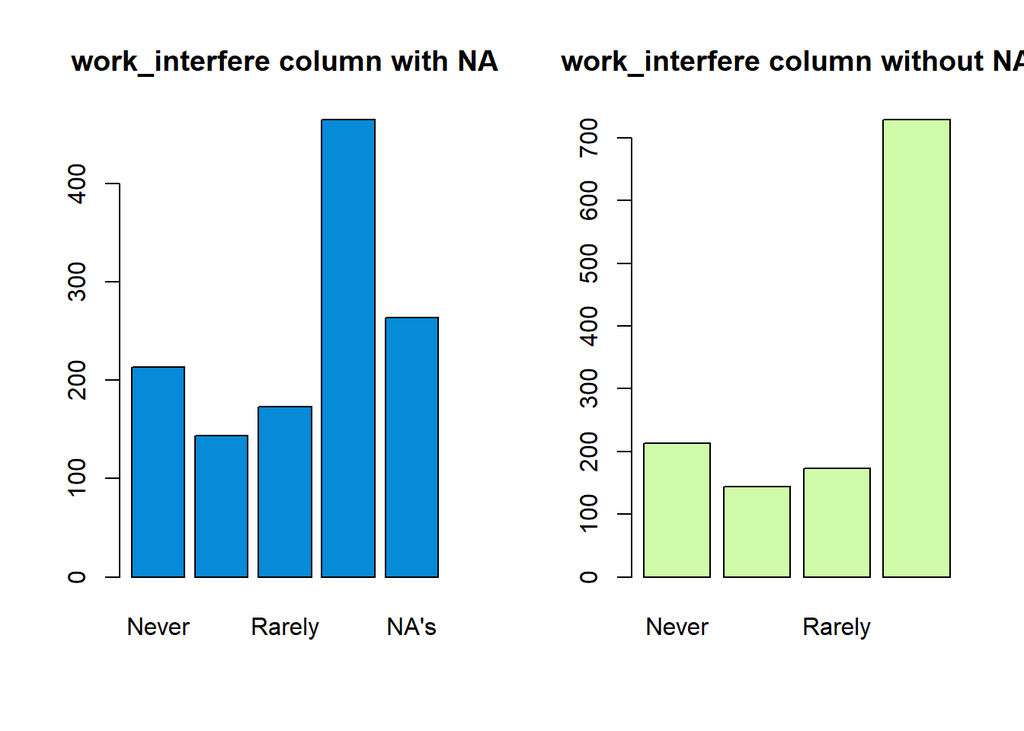

```r
#Observing the difference before and after imputationn
par(mfrow=c(1,2))
barplot(summary(data$work_interfere),col = "#078AD7",main = "work_interfere column with NA")
barplot(table(MH_data$work_interfere),col = "#D0FCA9",main = "work_interfere column without NA")
```

```r
#Storing cleaned data for Tableau Visualization
write.table(MH_data,"TableauDataCSV.csv", sep = ",",col.names = !file.exists("myDF.csv"), append = T,row.names = FALSE)
#Remove unwanted columns
#Comments,country,state,and timestamp are unwanted
#columns so we remove it from that dataset
MH_data <- MH_data[,c(-1,-4,-5,-27)]

#Verifying Cleaned data
summary(MH_data)
```

```
##       Age           Gender    self_employed family_history treatment
##  Min.   :18.00   female:251   No :1113      No :767        No :622
##  1st Qu.:27.00   male  :991   Yes: 146      Yes:492        Yes:637
##  Median :31.00   queer : 17
##  Mean   :32.07
##  3rd Qu.:36.00
##  Max.   :72.00
##    work_interfere         no_employees remote_work tech_company
##  Never    :213    1-5           :162   No :883     No : 228
##  Often    :144    100-500       :176   Yes:376     Yes:1031
##  Rarely   :173    26-100        :289
##  Sometimes:729    500-1000      : 60
##                   6-25          :290
##                   More than 1000:282
##        benefits     care_options   wellness_program      seek_help
##  Don't know:408   No      :501   Don't know:188     Don't know:363
##  No        :374   Not sure:314   No        :842     No        :646
##  Yes       :477   Yes     :444   Yes       :229     Yes       :250
##
##
##
##       anonymity                  leave     mental_health_consequence
##  Don't know:819   Don't know        :563   Maybe:477
##  No        : 65   Somewhat difficult:126   No   :490
##  Yes       :375   Somewhat easy     :266   Yes  :292
##                   Very difficult    : 98
##                   Very easy         :206
##
##  phys_health_consequence        coworkers          supervisor
##  Maybe:273               No          :260   No          :393
##  No   :925               Some of them:774   Some of them:350
##  Yes  : 61               Yes         :225   Yes         :516
##
##
##
##  mental_health_interview phys_health_interview  mental_vs_physical
##  Maybe: 207              Maybe:557             Don't know:576
##  No   :1008              No   :500             No        :340
##  Yes  :  44              Yes  :202             Yes       :343
##
##
##
##  obs_consequence
##  No :1075
##  Yes: 184
##
##
##
##
```

```r
#No NA values present after cleaning
sapply(MH_data, function(x) sum(is.na(x)))
```

```
##                       Age                    Gender             self_employed
##                         0                         0                         0
##            family_history                 treatment            work_interfere
##                         0                         0                         0
##              no_employees               remote_work              tech_company
##                         0                         0                         0
##                  benefits              care_options          wellness_program
##                         0                         0                         0
##                 seek_help                 anonymity                     leave
##                         0                         0                         0
## mental_health_consequence   phys_health_consequence                 coworkers
##                         0                         0                         0
##                supervisor   mental_health_interview     phys_health_interview
##                         0                         0                         0
##        mental_vs_physical           obs_consequence
##                         0                         0
```

```r
#Creating a copy of factor dataset for categorical classifiers
MH_data_factors <- MH_data
```

### Feature Engineering - Dummy codes

- Since the whole data is categorical, I have already used factors datatype.
- So instead of dummy coding each column, I just converted the factors data to numeric which does the dummy coding part
- I have also stored the original factor dataset in a variable called MH_data_factors
- This numeric data is used only for neural network classifier and for correlation analysis, other than that all other algorithms make use of factor dataset

```r
########################################
### Feature engineering: dummy codes ###
########################################

#we have factor dataset, on converting it to numeric we get dummy codes
str(MH_data)
```

```
## 'data.frame':    1259 obs. of  23 variables:
##  $ Age                      : num  37 44 32 31 31 33 35 39 42 23 ...
##  $ Gender                   : Factor w/ 3 levels "female","male",..: 1 2 2 2 2 2 1 2 1 2 ...
##  $ self_employed            : Factor w/ 2 levels "No","Yes": 1 1 1 1 1 1 1 1 1 1 ...
##  $ family_history           : Factor w/ 2 levels "No","Yes": 1 1 1 2 1 2 2 1 2 1 ...
##  $ treatment                : Factor w/ 2 levels "No","Yes": 2 1 1 2 1 1 2 1 2 1 ...
##  $ work_interfere           : Factor w/ 4 levels "Never","Often",..: 2 3 3 2 1 4 4 1 4 1 ...
##  $ no_employees             : Factor w/ 6 levels "1-5","100-500",..: 5 6 5 3 2 5 1 1 2 3 ...
##  $ remote_work              : Factor w/ 2 levels "No","Yes": 1 1 1 1 2 1 2 2 1 1 ...
##  $ tech_company             : Factor w/ 2 levels "No","Yes": 2 1 2 2 2 2 2 2 2 2 ...
##  $ benefits                 : Factor w/ 3 levels "Don't know","No",..: 3 1 2 2 3 3 2 2 3 1 ...
##  $ care_options             : Factor w/ 3 levels "No","Not sure",..: 2 1 1 3 1 2 1 3 3 1 ...
##  $ wellness_program         : Factor w/ 3 levels "Don't know","No",..: 2 1 2 2 1 2 2 2 2 1 ...
##  $ seek_help                : Factor w/ 3 levels "Don't know","No",..: 3 1 2 2 1 1 2 2 2 1 ...
##  $ anonymity                : Factor w/ 3 levels "Don't know","No",..: 3 1 1 2 1 1 2 3 2 1 ...
##  $ leave                    : Factor w/ 5 levels "Don't know","Somewhat difficult",..: 3 1 2 2 1 1 2 1 4 1 ...
##  $ mental_health_consequence: Factor w/ 3 levels "Maybe","No","Yes": 2 1 2 3 2 2 1 2 1 2 ...
##  $ phys_health_consequence  : Factor w/ 3 levels "Maybe","No","Yes": 2 2 2 3 2 2 1 2 2 2 ...
##  $ coworkers                : Factor w/ 3 levels "No","Some of them",..: 2 1 3 2 2 3 2 1 3 3 ...
##  $ supervisor               : Factor w/ 3 levels "No","Some of them",..: 3 1 3 1 3 3 1 1 3 3 ...
##  $ mental_health_interview  : Factor w/ 3 levels "Maybe","No","Yes": 2 2 3 1 3 2 2 2 2 1 ...
##  $ phys_health_interview    : Factor w/ 3 levels "Maybe","No","Yes": 1 2 3 1 3 1 2 2 1 1 ...
##  $ mental_vs_physical       : Factor w/ 3 levels "Don't know","No",..: 3 1 2 2 1 1 1 2 2 3 ...
##  $ obs_consequence          : Factor w/ 2 levels "No","Yes": 1 1 1 2 1 1 1 1 1 1 ...
```

```r
#Since Neural Network takes in only numeric data
#We convert the cleaned data to numeric type
#Converting to numeric will also do the dummy coding as the data was of
#factor type so converting to numeric makes it dummy coded
for (i in 1:ncol(MH_data)){
  if(is.factor(MH_data[,i] )){
    MH_data[,i] <- as.numeric(MH_data[,i])
  }
}

#Verifying the structure of the dataset
str(MH_data)
```

```
## 'data.frame':    1259 obs. of  23 variables:
##  $ Age                      : num  37 44 32 31 31 33 35 39 42 23 ...
##  $ Gender                   : num  1 2 2 2 2 2 1 2 1 2 ...
##  $ self_employed            : num  1 1 1 1 1 1 1 1 1 1 ...
##  $ family_history           : num  1 1 1 2 1 2 2 1 2 1 ...
##  $ treatment                : num  2 1 1 2 1 1 2 1 2 1 ...
##  $ work_interfere           : num  2 3 3 2 1 4 4 1 4 1 ...
##  $ no_employees             : num  5 6 5 3 2 5 1 1 2 3 ...
##  $ remote_work              : num  1 1 1 1 2 1 2 2 1 1 ...
##  $ tech_company             : num  2 1 2 2 2 2 2 2 2 2 ...
##  $ benefits                 : num  3 1 2 2 3 3 2 2 3 1 ...
##  $ care_options             : num  2 1 1 3 1 2 1 3 3 1 ...
##  $ wellness_program         : num  2 1 2 2 1 2 2 2 2 1 ...
##  $ seek_help                : num  3 1 2 2 1 1 2 2 2 1 ...
##  $ anonymity                : num  3 1 1 2 1 1 2 3 2 1 ...
##  $ leave                    : num  3 1 2 2 1 1 2 1 4 1 ...
##  $ mental_health_consequence: num  2 1 2 3 2 2 1 2 1 2 ...
##  $ phys_health_consequence  : num  2 2 2 3 2 2 1 2 2 2 ...
##  $ coworkers                : num  2 1 3 2 2 3 2 1 3 3 ...
##  $ supervisor               : num  3 1 3 1 3 3 1 1 3 3 ...
##  $ mental_health_interview  : num  2 2 3 1 3 2 2 2 2 1 ...
##  $ phys_health_interview    : num  1 2 3 1 3 1 2 2 1 1 ...
##  $ mental_vs_physical       : num  3 1 2 2 1 1 1 2 2 3 ...
##  $ obs_consequence          : num  1 1 1 2 1 1 1 1 1 1 ...
```

```r
#########################################
### Correlation/collinearity analysis ###
#########################################

#Creating a correlation plot of whole dataset
cormat <- round(cor(MH_data),2)
cormat
```

```
##                             Age Gender self_employed family_history treatment
## Age                        1.00   0.06          0.07           0.01      0.07
## Gender                     0.06   1.00          0.06          -0.12     -0.15
## self_employed              0.07   0.06          1.00           0.01      0.02
## family_history             0.01  -0.12          0.01           1.00      0.38
## treatment                  0.07  -0.15          0.02           0.38      1.00
## work_interfere            -0.04  -0.04         -0.03           0.10      0.13
## no_employees               0.03   0.01         -0.34          -0.05     -0.05
## remote_work                0.15   0.02          0.32           0.01      0.03
## tech_company              -0.06   0.08          0.08          -0.05     -0.03
## benefits                   0.15  -0.09         -0.05           0.13      0.23
## care_options               0.11  -0.09          0.05           0.11      0.24
## wellness_program           0.10   0.00          0.01           0.07      0.09
## seek_help                  0.13  -0.01          0.04           0.05      0.09
## anonymity                  0.02  -0.01          0.11           0.06      0.14
## leave                     -0.01   0.05          0.18           0.02      0.06
## mental_health_consequence  0.03   0.04          0.03           0.03      0.03
## phys_health_consequence   -0.05   0.05          0.03           0.00     -0.01
## coworkers                 -0.01   0.06          0.08           0.00      0.07
## supervisor                 0.01   0.07          0.04           0.00     -0.04
## mental_health_interview    0.06  -0.03         -0.01           0.04      0.10
## phys_health_interview     -0.02  -0.01         -0.02           0.04      0.05
## mental_vs_physical        -0.01  -0.01          0.14           0.04      0.06
## obs_consequence            0.07  -0.05          0.08           0.12      0.16
##                           work_interfere no_employees remote_work tech_company
## Age                                -0.04         0.03        0.15        -0.06
## Gender                             -0.04         0.01        0.02         0.08
## self_employed                      -0.03        -0.34        0.32         0.08
## family_history                      0.10        -0.05        0.01        -0.05
## treatment                           0.13        -0.05        0.03        -0.03
## work_interfere                      1.00         0.01        0.01         0.01
## no_employees                        0.01         1.00       -0.21        -0.11
## remote_work                         0.01        -0.21        1.00         0.13
## tech_company                        0.01        -0.11        0.13         1.00
## benefits                            0.00         0.12       -0.06        -0.05
## care_options                        0.01        -0.01        0.01        -0.03
## wellness_program                    0.00         0.09       -0.07        -0.12
## seek_help                           0.02         0.06       -0.03        -0.07
## anonymity                           0.04        -0.01        0.00        -0.05
## leave                               0.00        -0.10        0.10         0.05
```

[output cut: 113 more lines]

```
## tech_company                            0.03           -0.06
## benefits                                0.14            0.07
## care_options                            0.16            0.07
## wellness_program                        0.12            0.10
## seek_help                               0.17            0.13
## anonymity                               0.29            0.05
## leave                                   0.31            0.02
## mental_health_consequence               0.07            0.13
## phys_health_consequence                 0.11           -0.03
## coworkers                               0.19           -0.04
## supervisor                              0.23           -0.09
## mental_health_interview                -0.10            0.09
## phys_health_interview                   0.02            0.01
## mental_vs_physical                      1.00            0.02
## obs_consequence                         0.02            1.00
```

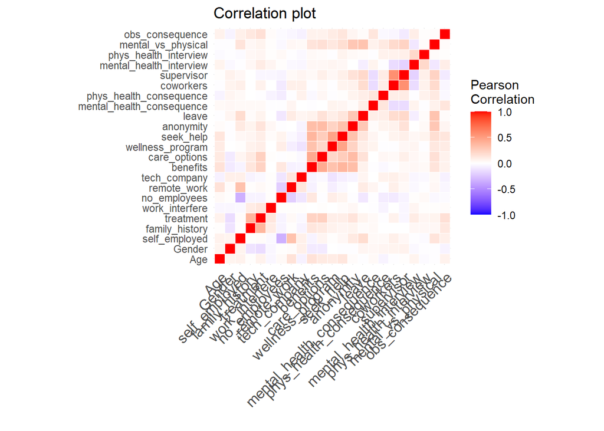

```r
melted_cormat <- melt(cormat)
ggplot(data = melted_cormat, aes(Var2, Var1, fill = value))+
 geom_tile(color = "white")+
 scale_fill_gradient2(low = "blue", high = "red", mid = "white",
   midpoint = 0, limit = c(-1,1), space = "Lab",
   name="Pearson\nCorrelation") +
  theme_minimal()+
 theme(axis.text.x = element_text(angle = 45, vjust = 1,
    size = 12, hjust = 1))+
 coord_fixed()+xlab("")+ylab("")+ggtitle("Correlation plot")
```

```r
#Observing correlation of all features with treatment feature
correlations <- as.data.frame(round(cor(MH_data[,-8],MH_data$treatment),2))
names <- rownames(correlations)
rownames(correlations) <- NULL
correlations <- cbind(names,correlations)
correlations <- correlations[order(-correlations$V1),]
correlations$V1 <- abs(correlations$V1)
correlations
```

|  | names | V1 |
| --- | --- | --- |
| 5 | treatment | 1.00 |
| 4 | family_history | 0.38 |
| 10 | care_options | 0.24 |
| 9 | benefits | 0.23 |
| 22 | obs_consequence | 0.16 |
| 13 | anonymity | 0.14 |
| 6 | work_interfere | 0.13 |
| 19 | mental_health_interview | 0.10 |
| 11 | wellness_program | 0.09 |
| 12 | seek_help | 0.09 |

[output cut: 12 more lines]

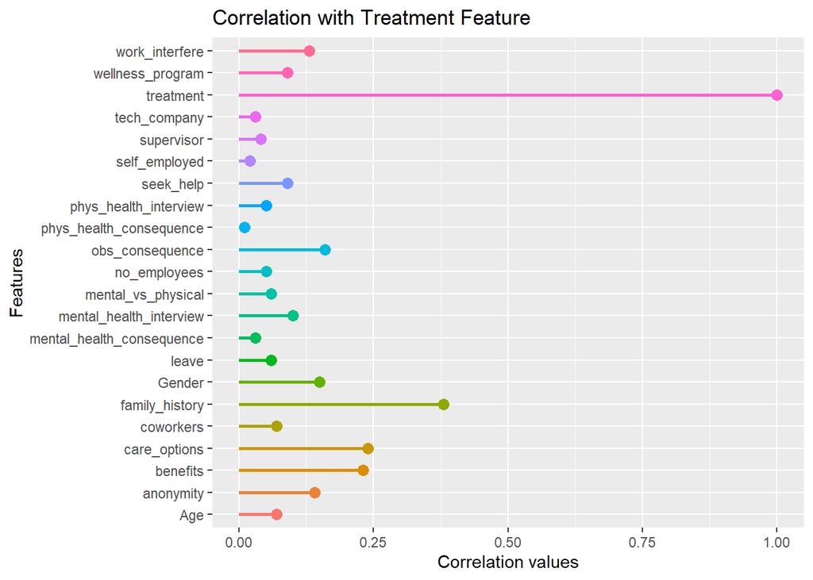

```r
#Plotting the correlation of all features with treatment feature
ggplot(data = correlations, aes(x = V1, y = names, color = names, group = names))+
  geom_segment(data = correlations,aes(x=0,xend = V1, y = names, yend = names),size = 1)+
  geom_point(size = 3)+ggtitle("Correlation with Treatment Feature")+
  theme(legend.position = "none")+xlab("Correlation values")+ylab("Features")
```

```r
#I also tried pairs.panels function for
#correlation but since there are more than 15 features
#Plots are not clearly visible
#pairs.panels(MH_data)
```

3. Data Cleaning & Shaping

### Data Imputation

- Data imputation is already done in previous chunks
- Imputation for age, self_employed and work_interfere is done

### Proper Encoding of Data

- Encoding was done for only Age column
- Age is categorized into three types Fresher, Junior and Senior

### Normalization/Standardization

- Normalizing the data did not make any difference in predictions
- This is because the data is categorical and not continous
- So I have not used normalized data for my models

### Feature engineering - PCA

- Principal component analysis is also done using prComp function
- On observing the summary of the principal components, I got to know that reducing the features won’t help much because there was very less amount of variance in the principal components
- Principal components are taken into consideration only when the cumulative variance is greater than 85%
- To get the cumulative variance of 85 or greater, I was forced to select 17 components which is almost the same as using 23 components
- Because of this I haven’t used Principal components for my models

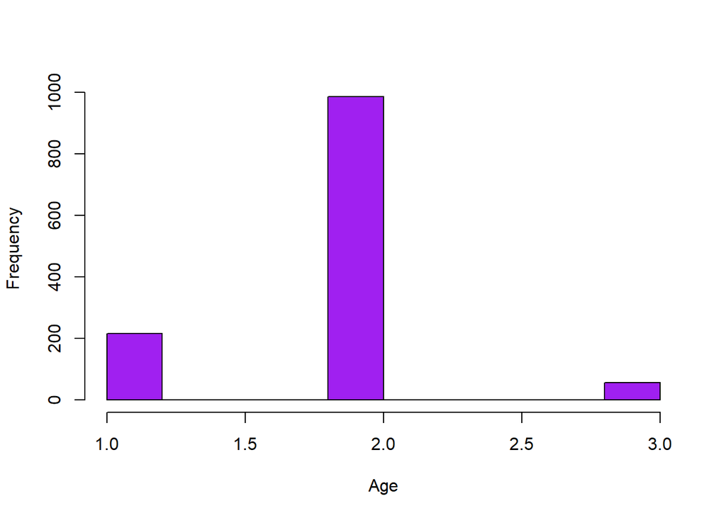

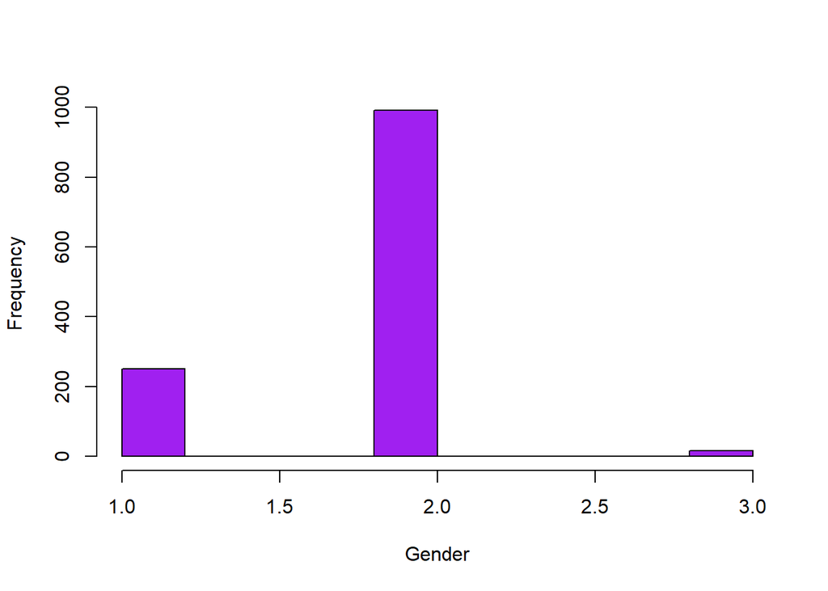

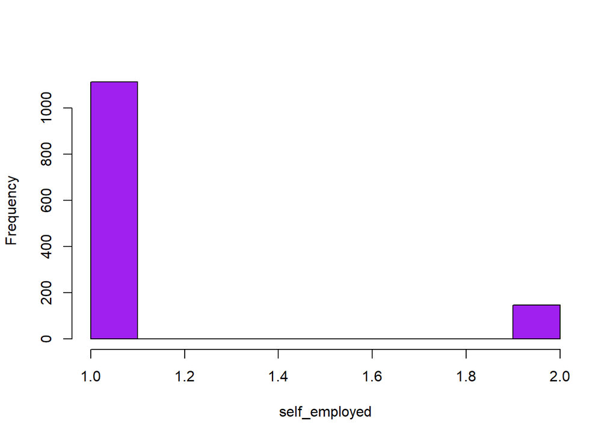

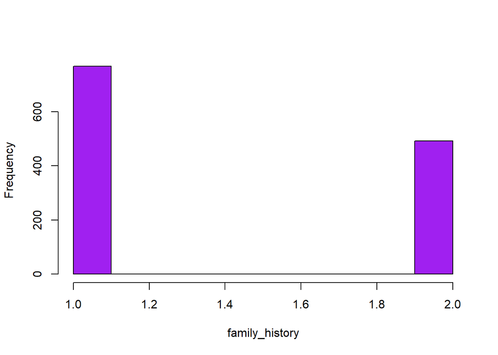

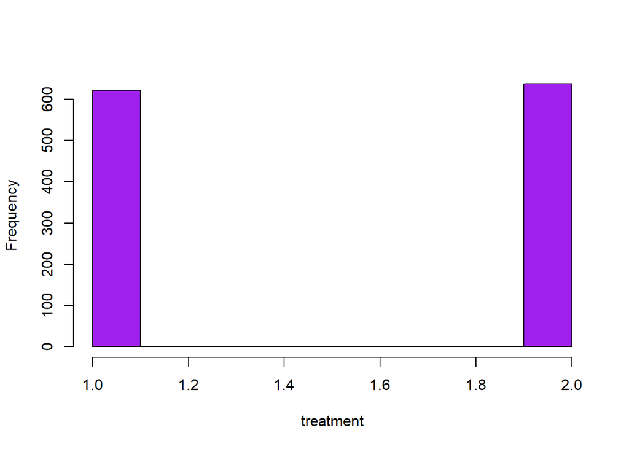

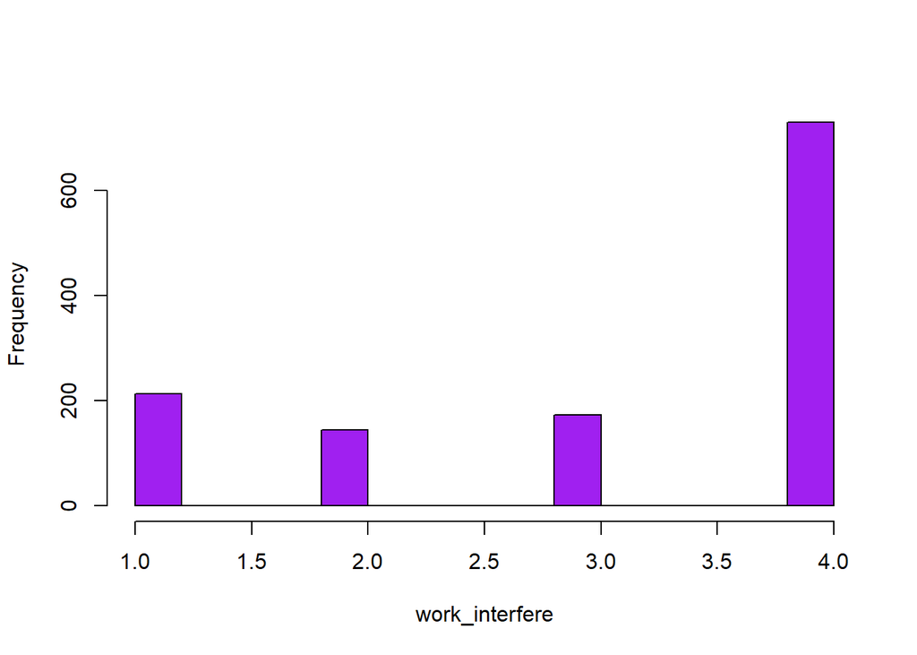

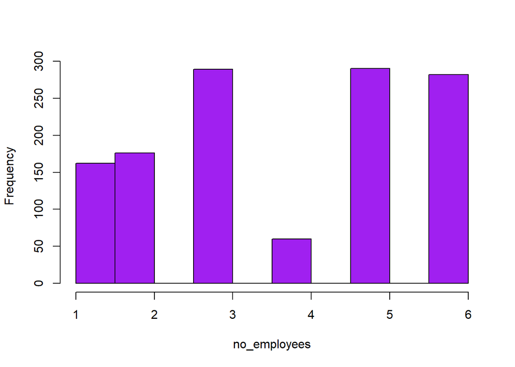

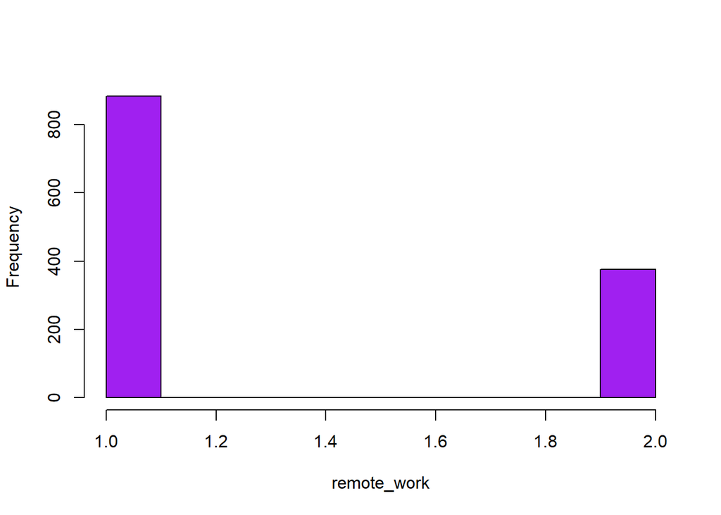

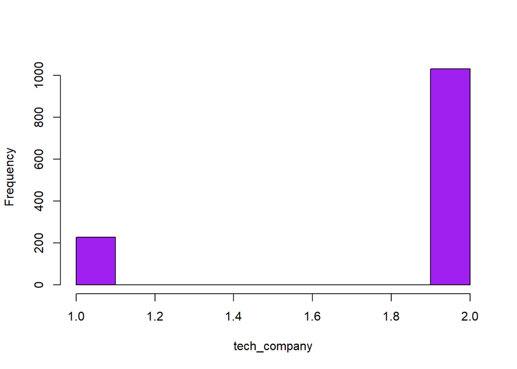

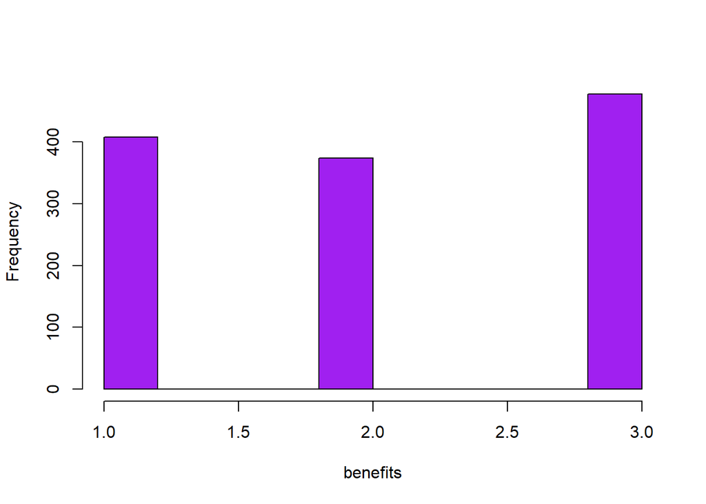

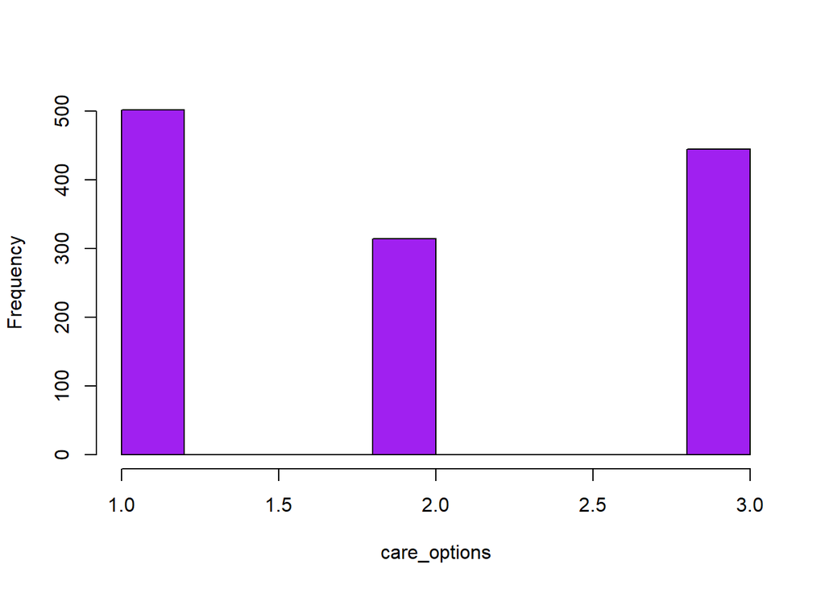

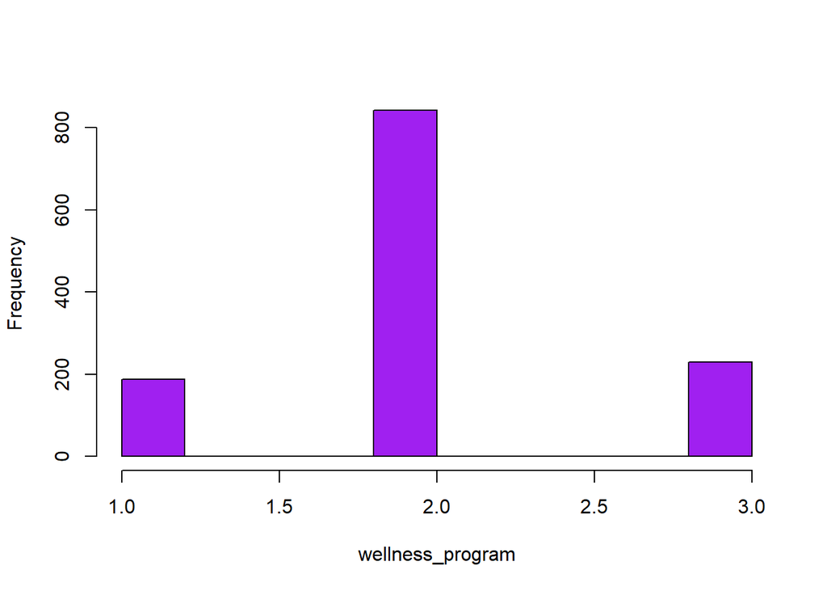

[11 more figures not shown]

```r
###################################################
### Proper encoding of data for algorithms used ###
###################################################

#Encoding of Age column to 3 types
MH_data$Age <- cut(MH_data$Age, breaks = c(15, 25, 45, 75), labels = c('Fresher', 'Junior', 'Senior'))
MH_data_factors$Age <- as.factor(cut(MH_data_factors$Age, breaks = c(15, 25, 45, 75), labels = c('Fresher', 'Junior', 'Senior')))

#Using as.numeric will convert the encoded data to dummy codes
MH_data$Age <- as.numeric(MH_data$Age)

#Observing the distribution of the data
for (i in 1:ncol(MH_data)) {
  hist(MH_data[,i],col="purple", xlab = colnames(MH_data[i]), main = NULL)
}
```

```r
#######################################################
### Normalization/standardization of feature values ###
#######################################################

#Normalization function
normalize <- function(x) {
  return((x - min(x)) / (max(x) - min(x)))
}

#Observing the new structure of the data after encoding Age feature
str(MH_data)
```

```
## 'data.frame':    1259 obs. of  23 variables:
##  $ Age                      : num  2 2 2 2 2 2 2 2 2 1 ...
##  $ Gender                   : num  1 2 2 2 2 2 1 2 1 2 ...
##  $ self_employed            : num  1 1 1 1 1 1 1 1 1 1 ...
##  $ family_history           : num  1 1 1 2 1 2 2 1 2 1 ...
##  $ treatment                : num  2 1 1 2 1 1 2 1 2 1 ...
##  $ work_interfere           : num  2 3 3 2 1 4 4 1 4 1 ...
##  $ no_employees             : num  5 6 5 3 2 5 1 1 2 3 ...
##  $ remote_work              : num  1 1 1 1 2 1 2 2 1 1 ...
##  $ tech_company             : num  2 1 2 2 2 2 2 2 2 2 ...
##  $ benefits                 : num  3 1 2 2 3 3 2 2 3 1 ...
##  $ care_options             : num  2 1 1 3 1 2 1 3 3 1 ...
##  $ wellness_program         : num  2 1 2 2 1 2 2 2 2 1 ...
##  $ seek_help                : num  3 1 2 2 1 1 2 2 2 1 ...
##  $ anonymity                : num  3 1 1 2 1 1 2 3 2 1 ...
##  $ leave                    : num  3 1 2 2 1 1 2 1 4 1 ...
##  $ mental_health_consequence: num  2 1 2 3 2 2 1 2 1 2 ...
##  $ phys_health_consequence  : num  2 2 2 3 2 2 1 2 2 2 ...
##  $ coworkers                : num  2 1 3 2 2 3 2 1 3 3 ...
##  $ supervisor               : num  3 1 3 1 3 3 1 1 3 3 ...
##  $ mental_health_interview  : num  2 2 3 1 3 2 2 2 2 1 ...
##  $ phys_health_interview    : num  1 2 3 1 3 1 2 2 1 1 ...
##  $ mental_vs_physical       : num  3 1 2 2 1 1 1 2 2 3 ...
##  $ obs_consequence          : num  1 1 1 2 1 1 1 1 1 1 ...
```

```r
#Creating a new normalized dataframe
MH_norm <- MH_data

#Normalizing the whole dataset
#Since the data is categorical it makes no sense to use the normalize data
#I tried model evaluation with normalized dataset it made no
#difference so I have just stored it
MH_norm[,-6] <- lapply(MH_data[,-6], normalize)
MH_norm[,6] <- as.factor(MH_data[,6])

################################
### Feature engineering: PCA ###
################################

#Performing PCA on the dataset
MH_PCA <- prcomp(MH_data[,-6], center = T, scale = T)

#Printing Principal components
print(MH_PCA)
```

```
## Standard deviations (1, .., p=22):
##  [1] 1.6840311 1.4596075 1.2851152 1.1837151 1.1109269 1.0815577 1.0226352
##  [8] 1.0067076 0.9501603 0.9483603 0.9290110 0.9135262 0.8784473 0.8523719
## [15] 0.8322443 0.8148475 0.7781787 0.7687332 0.7530433 0.7208846 0.7012437
## [22] 0.6229863
##
## Rotation (n x k) = (22 x 22):
##                                    PC1         PC2         PC3         PC4
## Age                       -0.088424372 -0.03359873  0.10397333 -0.21722259
## Gender                     0.049956472  0.16375107 -0.08221385 -0.34884462
## self_employed             -0.106610427  0.27493933  0.42886360 -0.15110859
## family_history            -0.154282565 -0.11900630  0.22382246  0.47037309
## treatment                 -0.232271270 -0.14321021  0.24244221  0.45000213
## no_employees               0.018418456 -0.27259094 -0.41128912 -0.05814209
## remote_work               -0.022443597  0.25115665  0.38461571 -0.07090230
## tech_company               0.042291755  0.22121691  0.12170552 -0.04996009
## benefits                  -0.375159682 -0.22254475 -0.08789274 -0.01601984
## care_options              -0.365951493 -0.09926413  0.02194666  0.04569248
## wellness_program          -0.318595719 -0.18539511 -0.10351649 -0.23663129
## seek_help                 -0.373950997 -0.12783348 -0.09805561 -0.22914090
## anonymity                 -0.390495085  0.02077367 -0.04152067 -0.10241060
## leave                     -0.257179624  0.26352547  0.05371667 -0.10652540
## mental_health_consequence -0.038633111 -0.08280877  0.26604974 -0.28630524
## phys_health_consequence   -0.063817887  0.15578805  0.01806694 -0.04645876
## coworkers                 -0.152362760  0.41175933 -0.22545427  0.27285769
## supervisor                -0.180075787  0.40493817 -0.32060865  0.20226311
## mental_health_interview   -0.008661403 -0.24213026  0.20387533  0.02257053
## phys_health_interview     -0.059164846 -0.01383769 -0.02342804  0.18689301
## mental_vs_physical        -0.289356527  0.21677291 -0.04291431 -0.07354014
## obs_consequence           -0.121613434 -0.15825486  0.23643315  0.02478391
##                                   PC5          PC6          PC7           PC8
## Age                        0.21319907 -0.403835101  0.002542382 -0.4459379665
## Gender                    -0.13519578 -0.175185347 -0.141633198 -0.3015686944
## self_employed              0.13208106 -0.096918033 -0.155977120  0.2343986191
## family_history            -0.03216240  0.138391758 -0.102924927 -0.2484304985
## treatment                  0.01325878  0.046171609  0.021619927 -0.2227876190
## no_employees              -0.09061892  0.045731791  0.035236677 -0.1422145393
## remote_work                0.22016956 -0.164311551  0.082384844  0.0155410470
## tech_company               0.04654817 -0.048133260  0.464631372 -0.3533132476
## benefits                   0.18481228 -0.063906923  0.247110820 -0.0827633438
```

[output cut: 90 more lines]

```
## tech_company              -0.003601179 -0.002884185
## benefits                   0.580529669  0.049582483
## care_options              -0.376872121 -0.108245858
## wellness_program           0.329132497 -0.088919901
## seek_help                 -0.600331184  0.098754775
## anonymity                  0.083729849 -0.127119066
## leave                      0.049789435  0.013081121
## mental_health_consequence  0.010194496 -0.016660088
## phys_health_consequence    0.035859356  0.015716707
## coworkers                  0.011015032 -0.646052111
## supervisor                 0.049187479  0.671084620
## mental_health_interview    0.005864944  0.050924550
## phys_health_interview      0.054297802 -0.050650854
## mental_vs_physical        -0.030332616 -0.004703564
## obs_consequence            0.104967888  0.033937527
```

```r
#Summary of Principal components
summary(MH_PCA)
```

```
## Importance of components:
##                           PC1     PC2     PC3     PC4    PC5     PC6     PC7
## Standard deviation     1.6840 1.45961 1.28512 1.18372 1.1109 1.08156 1.02264
## Proportion of Variance 0.1289 0.09684 0.07507 0.06369 0.0561 0.05317 0.04754
## Cumulative Proportion  0.1289 0.22575 0.30082 0.36451 0.4206 0.47377 0.52131
##                            PC8     PC9    PC10    PC11    PC12    PC13    PC14
## Standard deviation     1.00671 0.95016 0.94836 0.92901 0.91353 0.87845 0.85237
## Proportion of Variance 0.04607 0.04104 0.04088 0.03923 0.03793 0.03508 0.03302
## Cumulative Proportion  0.56738 0.60841 0.64929 0.68852 0.72646 0.76153 0.79456
##                           PC15    PC16    PC17    PC18    PC19    PC20    PC21
## Standard deviation     0.83224 0.81485 0.77818 0.76873 0.75304 0.72088 0.70124
## Proportion of Variance 0.03148 0.03018 0.02753 0.02686 0.02578 0.02362 0.02235
## Cumulative Proportion  0.82604 0.85622 0.88375 0.91061 0.93639 0.96001 0.98236
##                           PC22
## Standard deviation     0.62299
## Proportion of Variance 0.01764
## Cumulative Proportion  1.00000
```

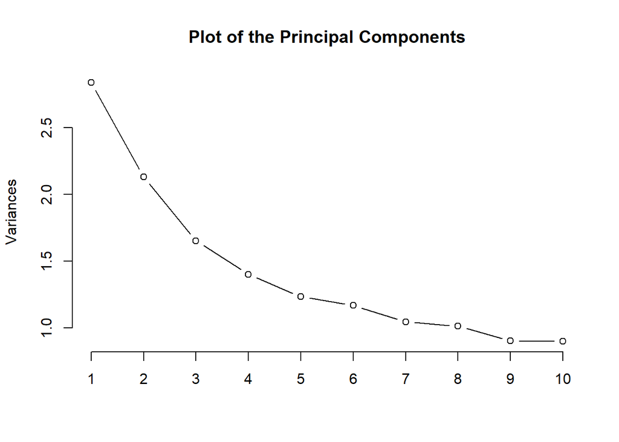

```r
#Plotting variance plot of the Principal components
screeplot(MH_PCA, type = "l", main = "Plot of the Principal Components")
```

```r
#Based on the summary we can see that there is not much of a variance present.
#It is advisable to use PCA when the cumulative proportion is above 85%
#On observing the cumulative proportion we see that, a total of 17 components will
#be needed to make up 88% of the data which makes no sense because we will be reducing only 5 features
#Reducing the features won't increase the efficiency of the models based on  these components
#Hence I will not be using these principal components for evaluation of my models

write.table(MH_data,"shinyData.csv", sep = ",",col.names = !file.exists("shinyData.csv"), append = T,row.names = FALSE)
```

4. Model Construction & Evaluation

### Creation of training & validation subsets

- Data splitting is done in 75:25 ratio
- Partition is created using createDataPartition function

### Construction of at least three related models

- I built 4 models which are as follows:
  - Logistic Regression (glm)
  - Neural Network (neuralnet)
  - Support Vector Machine (ksvm)
  - Recursive Partitioning - Decision Trees (rpart)
- For Neural Network model, I have used the numeric dataset whereas for all other models factor dataset is used

### Evaluation of fit of models with holdout method

- For model evaluation I have created two functions, mean absolute error(MAE) and root mean squared error(RMSE)
- Along with that, I have calculated accuracy of each model using the confusionMatrix function
- I have also calculated AUC for each model

```r
#Function for evaluating mean absolute error
MAE <- function(actual, predicted)
{
  mean(abs(actual - predicted))
}

#Function for evaluating root mean squared error
RMSE <- function(actual, pred)
{
  return(sqrt(sum((actual-pred)^2)/length(actual)))
}
```

```r
#################################################
### Creation of training & validation subsets ###
#################################################

#Converting the predictor variable to factor
MH_data$treatment <- as.factor(MH_data$treatment)

#Setting the seed values for randomness
set.seed(101)

#Splitting the dataset into 75:25 ratio
index <- createDataPartition(MH_data$treatment, p=0.75, list = FALSE, times = 1)
#Using numeric dataset for Neural Network
training_data <- MH_data[index, ]
testing_data <- MH_data[-index, ]
#Using categorical dataset for glm,SVM and rpart
training_data_factor <- MH_data_factors[index, ]
testing_data_factor <- MH_data_factors[-index, ]
```

```r
###########################
### Logistic Regression ###
###########################

#Building the logistic regression model using glm function
lm <- glm( treatment~., data = training_data_factor, family = "binomial" )

#Observing the summary of the model
summary(lm)
```

```
##
## Call:
## glm(formula = treatment ~ ., family = "binomial", data = training_data_factor)
##
## Deviance Residuals:
##     Min       1Q   Median       3Q      Max
## -2.8239  -0.8090   0.1860   0.8026   2.6723
##
## Coefficients:
##                              Estimate Std. Error z value Pr(>|z|)
## (Intercept)                  -3.24310    0.67137  -4.831 1.36e-06 ***
## AgeJunior                     0.26337    0.22208   1.186 0.235654
## AgeSenior                     0.99091    0.49030   2.021 0.043277 *
## Gendermale                   -0.82016    0.21261  -3.858 0.000114 ***
## Genderqueer                  -0.13513    0.81308  -0.166 0.868008
## self_employedYes             -0.25971    0.31561  -0.823 0.410569
## family_historyYes             1.28243    0.17086   7.506 6.10e-14 ***
## work_interfereOften           3.18225    0.39499   8.057 7.84e-16 ***
## work_interfereRarely          2.25511    0.33019   6.830 8.51e-12 ***
## work_interfereSometimes       1.56644    0.26753   5.855 4.77e-09 ***
## no_employees100-500           0.14827    0.37130   0.399 0.689655
## no_employees26-100            0.19910    0.33381   0.596 0.550881
## no_employees500-1000         -0.60993    0.49880  -1.223 0.221406
## no_employees6-25             -0.03684    0.31411  -0.117 0.906632
## no_employeesMore than 1000   -0.11286    0.37633  -0.300 0.764262
## remote_workYes                0.13436    0.19302   0.696 0.486373
## tech_companyYes               0.24236    0.22514   1.076 0.281706
## benefitsNo                    0.04840    0.25441   0.190 0.849107
## benefitsYes                   0.37003    0.24989   1.481 0.138656
## care_optionsNot sure         -0.15895    0.22409  -0.709 0.478132
## care_optionsYes               0.63793    0.22564   2.827 0.004695 **
## wellness_programNo            0.16357    0.27837   0.588 0.556790
## wellness_programYes          -0.16549    0.33351  -0.496 0.619746
## seek_helpNo                  -0.47806    0.24336  -1.964 0.049477 *
## seek_helpYes                 -0.17256    0.29880  -0.578 0.563582
## anonymityNo                  -0.35534    0.39184  -0.907 0.364487
## anonymityYes                  0.55958    0.21903   2.555 0.010624 *
## leaveSomewhat difficult       0.56852    0.29465   1.930 0.053668 .
## leaveSomewhat easy            0.11588    0.22490   0.515 0.606363
## leaveVery difficult           0.79807    0.36532   2.185 0.028920 *
```

[output cut: 11 more lines]

```
## phys_health_interviewNo       0.09658    0.18895   0.511 0.609276
## phys_health_interviewYes      0.17631    0.27594   0.639 0.522861
## mental_vs_physicalNo         -0.03356    0.21925  -0.153 0.878329
## mental_vs_physicalYes        -0.03553    0.22877  -0.155 0.876593
## obs_consequenceYes            0.37952    0.25316   1.499 0.133848
## ---
## Signif. codes:  0 '***' 0.001 '**' 0.01 '*' 0.05 '.' 0.1 ' ' 1
##
## (Dispersion parameter for binomial family taken to be 1)
##
##     Null deviance: 1309.92  on 944  degrees of freedom
## Residual deviance:  945.08  on 899  degrees of freedom
## AIC: 1037.1
##
## Number of Fisher Scoring iterations: 5
```

```r
#Predicting the output for testing dataset
predict_prob <- predict(lm, testing_data_factor, type = "response")

#Since we recieve output as probability values we convert it
pred_glm <- as.factor(ifelse(predict_prob < 0.5, "No", "Yes"))

#Model evaluation using confusionMatrix, Accuracy, RMSE, MAE, and AUC
confusionMatrix(pred_glm,testing_data_factor$treatment)
```

```
## Confusion Matrix and Statistics
##
##           Reference
## Prediction  No Yes
##        No  123  35
##        Yes  32 124
##
##                Accuracy : 0.7866
##                  95% CI : (0.7371, 0.8306)
##     No Information Rate : 0.5064
##     P-Value [Acc > NIR] : <2e-16
##
##                   Kappa : 0.5733
##
##  Mcnemar's Test P-Value : 0.807
##
##             Sensitivity : 0.7935
##             Specificity : 0.7799
##          Pos Pred Value : 0.7785
##          Neg Pred Value : 0.7949
##              Prevalence : 0.4936
##          Detection Rate : 0.3917
##    Detection Prevalence : 0.5032
##       Balanced Accuracy : 0.7867
##
##        'Positive' Class : No
##
```

```r
accuracy_glm <- accuracy(pred_glm,testing_data_factor$treatment)
RMSE_glm <- RMSE(as.numeric(testing_data_factor$treatment), as.numeric(pred_glm))
MAE_glm <- MAE(as.numeric(testing_data_factor$treatment), as.numeric(pred_glm))
roc_glm <- roc(as.numeric(testing_data_factor$treatment), as.numeric(pred_glm))
```

```r
#Converting predictor feature to numeric for neural networks
training_data$treatment <- as.numeric(training_data$treatment)
testing_data$treatment <- as.numeric(testing_data$treatment)

######################
### Neural Network ###
######################

#Building neural network model with 1 hidden layer along with softplus function
softplus <- function(x) log(1+exp(x))
neuralnet_model <- neuralnet(treatment~., data = training_data,stepmax=1e+08,threshold = 0.5,rep = 1,linear.output = FALSE, act.fct = softplus)

#Using compute() function to predict the outcome of testing dataset
nn_predictions <- compute(neuralnet_model, testing_data[,-6])
net_results <- nn_predictions$net.result

#Checking the correlation of both predictor and predicted values
cor(net_results,as.numeric(testing_data$treatment))
```

```
##           [,1]
## [1,] 0.5601729
```

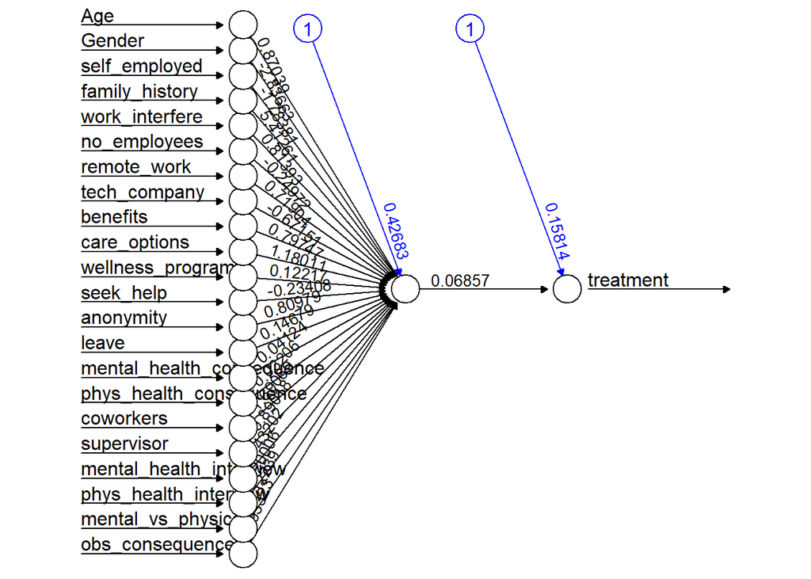

```r
#Plotting the neural network
plot(neuralnet_model, rep="best")
```

```r
#Converting the numeric prediction to category
pred_nn <- net_results
pred_nn <- as.factor(ifelse(pred_nn>1.5, 2, 1))

#Model evaluation using confusionMatrix, Accuracy, RMSE, MAE, and AUC
confusionMatrix(pred_nn,as.factor(testing_data$treatment))
```

```
## Confusion Matrix and Statistics
##
##           Reference
## Prediction   1   2
##          1 135  62
##          2  20  97
##
##                Accuracy : 0.7389
##                  95% CI : (0.6866, 0.7866)
##     No Information Rate : 0.5064
##     P-Value [Acc > NIR] : < 2.2e-16
##
##                   Kappa : 0.4794
##
##  Mcnemar's Test P-Value : 5.963e-06
##
##             Sensitivity : 0.8710
##             Specificity : 0.6101
##          Pos Pred Value : 0.6853
##          Neg Pred Value : 0.8291
##              Prevalence : 0.4936
##          Detection Rate : 0.4299
##    Detection Prevalence : 0.6274
##       Balanced Accuracy : 0.7405
##
##        'Positive' Class : 1
##
```

```r
accuracy_nn <- accuracy(pred_nn,as.factor(testing_data$treatment))
RMSE_nn <- RMSE(as.numeric(testing_data$treatment), as.numeric(pred_nn))
MAE_nn <- MAE(as.numeric(testing_data$treatment), as.numeric(pred_nn))
roc_nn <- roc(as.numeric(testing_data$treatment), as.numeric(pred_nn))
```

```r
##############################
### Support Vector Machine ###
##############################

#Building SVM model with categorical data
svm_model <- ksvm(treatment ~ ., data = training_data_factor,prob.model=TRUE,kernel="rbfdot")

#Predicting outcome of the testing dataset
pred_svm <- predict(svm_model, testing_data_factor)

#Observing first few predictions
head(pred_svm)
```

```
## [1] Yes Yes No  Yes Yes Yes
## Levels: No Yes
```

```r
#pred_svm <- as.factor(ifelse(pred_svm>1.5, 2, 1))

#Model evaluation using confusionMatrix, Accuracy, RMSE, MAE, and AUC
confusionMatrix(as.factor(pred_svm),as.factor(testing_data_factor$treatment))
```

```
## Confusion Matrix and Statistics
##
##           Reference
## Prediction  No Yes
##        No  121  45
##        Yes  34 114
##
##                Accuracy : 0.7484
##                  95% CI : (0.6966, 0.7955)
##     No Information Rate : 0.5064
##     P-Value [Acc > NIR] : <2e-16
##
##                   Kappa : 0.4972
##
##  Mcnemar's Test P-Value : 0.2606
##
##             Sensitivity : 0.7806
##             Specificity : 0.7170
##          Pos Pred Value : 0.7289
##          Neg Pred Value : 0.7703
##              Prevalence : 0.4936
##          Detection Rate : 0.3854
##    Detection Prevalence : 0.5287
##       Balanced Accuracy : 0.7488
##
##        'Positive' Class : No
##
```

```r
accuracy_svm <- accuracy(as.factor(pred_svm),as.factor(testing_data_factor$treatment))
RMSE_svm <- RMSE(as.numeric(testing_data_factor$treatment), as.numeric(pred_svm))
MAE_svm <- MAE(as.numeric(testing_data_factor$treatment), as.numeric(pred_svm))
roc_svm <- roc(as.numeric(testing_data_factor$treatment), as.numeric(pred_svm))
```

```r
###############################################
### Recursive Partitioning - Decision Trees ###
###############################################

#Building Decision tree model using rpart function
rpart_model <- rpart(treatment ~ ., data = training_data_factor[,-3],method = "class")
rpart_model
```

```
## n= 945
##
## node), split, n, loss, yval, (yprob)
##       * denotes terminal node
##
##  1) root 945 467 Yes (0.4941799 0.5058201)
##    2) family_history=No 573 208 No (0.6369983 0.3630017)
##      4) work_interfere=Never 127  14 No (0.8897638 0.1102362) *
##      5) work_interfere=Often,Rarely,Sometimes 446 194 No (0.5650224 0.4349776)
##       10) care_options=No,Not sure 303 103 No (0.6600660 0.3399340)
##         20) work_interfere=Rarely,Sometimes 270  80 No (0.7037037 0.2962963) *
##         21) work_interfere=Often 33  10 Yes (0.3030303 0.6969697) *
##       11) care_options=Yes 143  52 Yes (0.3636364 0.6363636) *
##    3) family_history=Yes 372 102 Yes (0.2741935 0.7258065)
##      6) work_interfere=Never 32  10 No (0.6875000 0.3125000) *
##      7) work_interfere=Often,Rarely,Sometimes 340  80 Yes (0.2352941 0.7647059) *
```

```r
#Observing the importance of each variable using summary
#We can see 45% of the predictions is dependent on family history feature
summary(rpart_model)
```

```
## Call:
## rpart(formula = treatment ~ ., data = training_data_factor[,
##     -3], method = "class")
##   n= 945
##
##           CP nsplit rel error    xerror       xstd
## 1 0.33618844      0 1.0000000 1.0406852 0.03289968
## 2 0.04175589      1 0.6638116 0.6638116 0.03090544
## 3 0.02783726      3 0.5802998 0.6102784 0.03021076
## 4 0.02569593      4 0.5524625 0.6124197 0.03024078
## 5 0.01000000      5 0.5267666 0.5781585 0.02973726
##
## Variable importance
##   family_history   work_interfere     care_options         benefits
##               45               33               13                2
##        anonymity  obs_consequence wellness_program        seek_help
##                2                2                1                1
##           Gender
##                1
##
## Node number 1: 945 observations,    complexity param=0.3361884
##   predicted class=Yes  expected loss=0.4941799  P(node) =1
##     class counts:   467   478
##    probabilities: 0.494 0.506
##   left son=2 (573 obs) right son=3 (372 obs)
##   Primary splits:
##       family_history splits as  LR,   improve=59.38019, (0 missing)
##       work_interfere splits as  LRRR, improve=48.14946, (0 missing)
##       care_options   splits as  LLR,  improve=31.51524, (0 missing)
##       Gender         splits as  RLR,  improve=20.36115, (0 missing)
##       benefits       splits as  LLR,  improve=16.85070, (0 missing)
##   Surrogate splits:
##       obs_consequence splits as  LR,   agree=0.621, adj=0.038, (0 split)
##       Gender          splits as  RLR,  agree=0.615, adj=0.022, (0 split)
##       work_interfere  splits as  LRLL, agree=0.615, adj=0.022, (0 split)
##
## Node number 2: 573 observations,    complexity param=0.04175589
##   predicted class=No   expected loss=0.3630017  P(node) =0.6063492
##     class counts:   365   208
##    probabilities: 0.637 0.363
```

[output cut: 64 more lines]

```
##
## Node number 11: 143 observations
##   predicted class=Yes  expected loss=0.3636364  P(node) =0.1513228
##     class counts:    52    91
##    probabilities: 0.364 0.636
##
## Node number 20: 270 observations
##   predicted class=No   expected loss=0.2962963  P(node) =0.2857143
##     class counts:   190    80
##    probabilities: 0.704 0.296
##
## Node number 21: 33 observations
##   predicted class=Yes  expected loss=0.3030303  P(node) =0.03492063
##     class counts:    10    23
##    probabilities: 0.303 0.697
```

[figure not shown]

```r
#plotting the tree using fancyRpartPlot function
fancyRpartPlot(rpart_model)
```

```r
#Predicting the outcome using testing dataset
pred_rpart <- predict(rpart_model, testing_data_factor)

#Since the output is in terms of probabilities we convert it to categorical values
pred_rpart <- as.factor(ifelse(pred_rpart[,2] < 0.5, "No", "Yes"))

#Model evaluation using confusionMatrix, Accuracy, RMSE, MAE, and AUC
confusionMatrix(pred_rpart,testing_data_factor$treatment)
```

```
## Confusion Matrix and Statistics
##
##           Reference
## Prediction  No Yes
##        No  120  27
##        Yes  35 132
##
##                Accuracy : 0.8025
##                  95% CI : (0.7542, 0.8451)
##     No Information Rate : 0.5064
##     P-Value [Acc > NIR] : <2e-16
##
##                   Kappa : 0.6048
##
##  Mcnemar's Test P-Value : 0.374
##
##             Sensitivity : 0.7742
##             Specificity : 0.8302
##          Pos Pred Value : 0.8163
##          Neg Pred Value : 0.7904
##              Prevalence : 0.4936
##          Detection Rate : 0.3822
##    Detection Prevalence : 0.4682
##       Balanced Accuracy : 0.8022
##
##        'Positive' Class : No
##
```

```r
accuracy_rpart <- accuracy(pred_rpart,testing_data_factor$treatment)
RMSE_rpart <- RMSE(as.numeric(testing_data_factor$treatment), as.numeric(pred_rpart))
MAE_rpart <- MAE(as.numeric(testing_data_factor$treatment), as.numeric(pred_rpart))
roc_rpart <- roc(as.numeric(testing_data_factor$treatment), as.numeric(pred_rpart))
```

### Evaluation with k-fold cross-validation

- k-Fold Cross Validation is done for the whole dataset
- I have used k = 10 which means 10 folds take place along with 3 repetitions
- For testing the data, I have used 3 models to test the k-fold CV
- Accuracy of each model is printed and based on the observation average accuracy is around 72-73%

```r
###############################
### K-fold Cross Validation ###
###############################

#Creating a train function for cross validation
#We use k = 10 folds with repeated validation
fitControl <- trainControl(## 10-fold CV
                           method = "repeatedcv",
                           number = 10,repeats = 3,savePredictions = TRUE)

#Cross validation is done using 3 models glm, SVM with
#Radial function, and rpart function
cv_glm <- train(treatment ~ ., data = MH_data_factors,
                 method = "glm",
                 trControl = fitControl)

cv_svm <- train(treatment ~ ., data = MH_data_factors,
                 method = "svmRadial",
                 trControl = fitControl)

cv_rpart <- train(treatment ~ ., data = MH_data_factors,
                 method = "rpart",
                 trControl = fitControl)

#Printing the accuracies of each model with cross validation
#cv_glm
print(cv_glm)
```

```
## Generalized Linear Model
##
## 1259 samples
##   22 predictor
##    2 classes: 'No', 'Yes'
##
## No pre-processing
## Resampling: Cross-Validated (10 fold, repeated 3 times)
## Summary of sample sizes: 1133, 1134, 1133, 1133, 1133, 1134, ...
## Resampling results:
##
##   Accuracy   Kappa
##   0.7381586  0.4762473
```

```r
#cv_svm
print(cv_svm)
```

```
## Support Vector Machines with Radial Basis Function Kernel
##
## 1259 samples
##   22 predictor
##    2 classes: 'No', 'Yes'
##
## No pre-processing
## Resampling: Cross-Validated (10 fold, repeated 3 times)
## Summary of sample sizes: 1134, 1133, 1133, 1133, 1133, 1134, ...
## Resampling results across tuning parameters:
##
##   C     Accuracy   Kappa
##   0.25  0.7355133  0.4711580
##   0.50  0.7434456  0.4869914
##   1.00  0.7442394  0.4886108
##
## Tuning parameter 'sigma' was held constant at a value of 0.01287498
## Accuracy was used to select the optimal model using the largest value.
## The final values used for the model were sigma = 0.01287498 and C = 1.
```

```r
#cv_rpart
print(cv_rpart)
```

```
## CART
##
## 1259 samples
##   22 predictor
##    2 classes: 'No', 'Yes'
##
## No pre-processing
## Resampling: Cross-Validated (10 fold, repeated 3 times)
## Summary of sample sizes: 1134, 1133, 1133, 1134, 1133, 1133, ...
## Resampling results across tuning parameters:
##
##   cp          Accuracy   Kappa
##   0.01982851  0.7039752  0.4077652
##   0.06109325  0.6875810  0.3766278
##   0.35852090  0.5720861  0.1390566
##
## Accuracy was used to select the optimal model using the largest value.
## The final value used for the model was cp = 0.01982851.
```